# Project_Helt_Apr26

**Purpose**  
The objective of this analysis is to identify diamond drilling projects within the Abitibi-Témiscamingue region that require helicopter support during non-winter operations. By filtering active drilling authorizations (a type of impact causing work authorization, or an ATI) and overlaying them with provincial rutting sensitivity data from multiple mapsheets, the demand for aerial logistics can be quantified. Projects with more than 50% coverage of moderate or high rutting sensitivity (sensitive wetland areas) are classified as requiring helicopter support. This assessment provides the data necessary to evaluate potential helicopter supply shortages and logistics hub requirements for the upcoming season.

**Step 1: Filter Drilling Authorizations and Standardize CRS**  
The primary dataset is filtered to isolate diamond drilling activities (Type_ATI = Forage au diamant) within the Abitibi-Témiscamingue region (Region_ADM = Abitibi-Témiscamingue). The filtered data is then reprojected from its native geographic coordinate system (EPSG:4269) to the provincial metric standard (EPSG:32198) to ensure spatial compatibility with forestry layers and to enable accurate area-based calculations.

```python
import geopandas as gpd
import pandas as pd
import os

# 1. Define the absolute path
zip_path = r"D:\QGIS\Spatial Thoughts\python_foundation\AUTOR_TRAV_IMPA_WORK_AUTHOR.zip"
shapefile_name = "ATI Actifs_Active ATI.shp"

# 2. Format the path specifically for the pyogrio/GDAL engine
# We replace backslashes with forward slashes for the virtual system
vsi_zip_path = zip_path.replace("\\", "/")
ati_path = f"/vsizip/{vsi_zip_path}/{shapefile_name}"

try:
    # Load the master ATI dataset (engine defaults to pyogrio here)
    # We use 'latin1' because many older Quebec SHP files use it for accents
    ati_master = gpd.read_file(ati_path, encoding='latin1')

    # 3. Filter for diamond drilling in Abitibi-Témiscamingue
    # Using 'str.contains' is safer if there are hidden spaces in the data
    ati_filtered = ati_master[
        (ati_master['Type_ATI'].str.contains('Forage au diamant', na=False)) &
        (ati_master['Region_ADM'].str.contains('Abitibi-Témiscamingue', na=False))
    ].copy()

    # 4. Reproject to Quebec Lambert (EPSG:32198)
    ati = ati_filtered.to_crs("EPSG:32198")

    # Validation
    print(f"Success! Filtered records: {len(ati)}")
    if len(ati) > 0:
        print(f"Projected CRS: {ati.crs.name}")
    else:
        print("Warning: 0 records found. Check if column names or region spellings match.")

except Exception as e:
    print(f"Error: {e}")
```

```
Success! Filtered records: 99
Projected CRS: NAD83 / Quebec Lambert
```

**Step 2: Spatial Clipping and Attribute Integration of Forestry Data**  
The provincial rutting data is distributed across nine separate GeoPackage mapsheets. To optimize processing performance, the high-density polygon layer (pee_ori) from each sheet is immediately clipped to the boundaries of the filtered ATI projects. Following the clip, the rutting constraint values (con_ornier) are joined to the resulting geometries using the shared geocode identifier.

```python
import glob
import os

# 1. Define folder containing the 9 mapsheets
mapsheet_folder = r"D:\QGIS\Spatial Thoughts\python_foundation\mapsheets"

# 2. Grab all .gpkg files in that folder
mapsheet_files = glob.glob(os.path.join(mapsheet_folder, "*.gpkg"))

processed_layers = []

print(f"Starting integration for {len(mapsheet_files)} mapsheets...")

for sheet in mapsheet_files:
    filename = os.path.basename(sheet)
    try:
        # Load polygons using the 'ati' object as a spatial mask
        # Note: mask=ati performs the clip during the read
        clipped_polygons = gpd.read_file(sheet, layer="pee_ori", mask=ati)

        if not clipped_polygons.empty:
            # Load the constraints table (corrected spelling)
            attr_table = gpd.read_file(sheet, layer="contraintes_pee_ori")

            # Select the join key and the rutting field
            attr_subset = attr_table[['geocode', 'con_ornier']]

            # Left join: Attach 'con_ornier' to our clipped polygons
            joined_clip = clipped_polygons.merge(attr_subset, on='geocode', how='left')

            processed_layers.append(joined_clip)
            print(f"Success: {filename} - {len(joined_clip)} intersections found.")
        else:
            print(f"Checked: {filename} - No spatial overlap with drilling projects.")

    except Exception as e:
        print(f"Error in {filename}: {e}")

print(f"\nProcessing finished. {len(processed_layers)} GeoDataFrames ready for merging.")
```

```
Starting integration for 9 mapsheets...
Success: PRODUITS_IEQM_31M.gpkg - 3598 intersections found.
Success: PRODUITS_IEQM_31N.gpkg - 477 intersections found.
Checked: PRODUITS_IEQM_31O.gpkg - No spatial overlap with drilling projects.
Success: PRODUITS_IEQM_32B.gpkg - 1377 intersections found.
Success: PRODUITS_IEQM_32C_C.gpkg - 6763 intersections found.
Success: PRODUITS_IEQM_32D_C.gpkg - 8313 intersections found.
Checked: PRODUITS_IEQM_32E_C.gpkg - No spatial overlap with drilling projects.
Success: PRODUITS_IEQM_32F_C.gpkg - 1711 intersections found.
Success: PRODUITS_IEQM_32G_C.gpkg - 367 intersections found.

Processing finished. 7 GeoDataFrames ready for merging.
```

```python
import pandas as pd
import os

if processed_layers:
    # 1. Merge into a single GeoDataFrame
    # We explicitly cast it as a GeoDataFrame and restore the CRS
    rutting_overlay = gpd.GeoDataFrame(pd.concat(processed_layers, ignore_index=True))
    rutting_overlay.crs = ati.crs

    # 2. Deduplicate
    # This prevents double-counting area on polygons that overlap mapsheet borders
    initial_count = len(rutting_overlay)
    rutting_overlay = rutting_overlay.drop_duplicates(subset=['geocode'])
    final_count = len(rutting_overlay)

    print(f"Consolidation: {initial_count} records merged, {final_count} unique records kept.")

    # 3. Secure Export with Absolute Path
    # Using the full path ensures you always know where your 'Check Point' is
    output_dir = r"D:\QGIS\Spatial Thoughts\python_foundation\output"
    if not os.path.exists(output_dir):
        os.makedirs(output_dir)

    output_path = os.path.join(output_dir, "ATI_Rutting_Overlay.gpkg")

    # Export for verification
    rutting_overlay.to_file(output_path, driver="GPKG", layer="rutting_analysis")

    print(f"--- SUCCESS ---")
    print(f"Regional rutting layer saved to: {output_path}")
    print(f"Unique classes for analysis: {rutting_overlay['con_ornier'].unique()}")

else:
    print("No spatial overlaps detected. Please check your mapsheet files and ATI filtering.")
```

```
Consolidation: 22606 records merged, 22307 unique records kept.
--- SUCCESS ---
Regional rutting layer saved to: D:\QGIS\Spatial Thoughts\python_foundation\output\ATI_Rutting_Overlay.gpkg
Unique classes for analysis: <StringArray>
['Faible', 'Élevé', nan, 'Modéré']
Length: 4, dtype: str
```

**Note:** The initial output successfully identified the spatial intersections between forestry polygons and the project sites, but lacked the specific project identifiers (Authorization Number, Project Name, and Company). The following code performs a Spatial Join to "stamp" those critical ATI attributes onto each individual rutting polygon.

```python
# Final Data Integration: Attaching ATI Project Details to Rutting Polygons

# 1. Select the specific fields needed for the boardroom report
# We include 'geometry' so Python knows how to align the layers
ati_subset = ati[['No_ATI', 'Nom_Projet', 'Demandeur', 'geometry']]

# 2. Perform the Spatial Join
# 'intersects' is used to ensure polygons sharing a boundary are captured
rutting_final = gpd.sjoin(
    rutting_overlay,
    ati_subset,
    how='left',
    predicate='intersects'
)

# 3. Clean up the internal join column created by Geopandas
if 'index_right' in rutting_final.columns:
    rutting_final = rutting_final.drop(columns=['index_right'])

# 4. Save the "Master Layer" with all identifying information
output_path = r"D:\QGIS\Spatial Thoughts\python_foundation\output\ATI_Rutting_Final.gpkg"
rutting_final.to_file(output_path, driver="GPKG", layer="rutting_by_project")

print("--- Integration Complete ---")
print(f"Total features with project data: {len(rutting_final)}")
print("\nPreview of the Integrated Data:")
print(rutting_final[['No_ATI', 'Nom_Projet', 'Demandeur', 'con_ornier']].head())
```

```
--- Integration Complete ---
Total features with project data: 24377

Preview of the Integrated Data:
    No_ATI Nom_Projet              Demandeur con_ornier
0  ATI-559   Gravitas     Neoterrex Minerals     Faible
1  ATI-559   Gravitas     Neoterrex Minerals     Faible
2  ATI-559   Gravitas     Neoterrex Minerals      Élevé
3  ATI-559   Gravitas     Neoterrex Minerals      Élevé
4  ATI-627   Lorraine  9426-9198 Quebec inc.     Faible
```

**Step 4: Hectare Calculation and Helicopter Support Requirement Assessment**  
With the consolidated rutting data, the final analytical step involves calculating the spatial footprint of each sensitivity category within each drilling authorization. By determining the percentage of area classified as Modéré or Élevé, projects requiring helicopter logistics can be isolated. Projects exceeding a 50% threshold for these combined categories are flagged as requiring aerial support to prevent terrain degradation during non-winter operations.

```python
# Step 4: Hectare Calculation and Helicopter Support Requirement Assessment

# 1. Area calculation
# We use the 'rutting_final' dataframe from your Step 3 join
rutting_final['area_m2'] = rutting_final.geometry.area

# 2. Group data by Project details and Sensitivity
# This handles the multiple lines by summing all polygons per ATI
summary = rutting_final.groupby(['No_ATI', 'Nom_Projet', 'Demandeur', 'con_ornier'])['area_m2'].sum().unstack(fill_value=0)

# 3. Calculate metrics: Total Area (m2), Total Hectares, and Risk Percentage
summary['total_area_m2'] = summary.sum(axis=1)
summary['total_ha'] = summary['total_area_m2'] / 10000

# We combine 'Modéré' and 'Élevé' to find the total sensitive footprint
summary['high_risk_pct'] = (
    (summary.get('Modéré', 0) + summary.get('Élevé', 0)) / summary['total_area_m2']
) * 100

# 4. Apply the 50% threshold for helicopter support
summary['Heli_Required'] = summary['high_risk_pct'] > 50

# 5. Merge findings back to the original ATI geometries for mapping
# We use reset_index() to turn the grouped labels back into mergeable columns
final_assessment = ati.merge(
    summary[['high_risk_pct', 'Heli_Required', 'total_ha']].reset_index(),
    on='No_ATI',
    how='left'
)

# 6. Export the final classification to a GeoPackage
output_assessment = r"D:\QGIS\Spatial Thoughts\python_foundation\output\Helicopter_Demand_Assessment.gpkg"
final_assessment.to_file(output_assessment, driver="GPKG", layer="final_heli_decision")

print("--- Requirement Assessment Complete ---")
print(f"Total Projects Processed: {len(summary)}")
print(f"Projects flagged for Helicopter: {summary['Heli_Required'].sum()}")
```

```
--- Requirement Assessment Complete ---
Total Projects Processed: 99
Projects flagged for Helicopter: 58
```

```python
# 1. Quick check to see what columns we actually have
print(f"Available columns: {final_assessment.columns.tolist()}")

# 2. Create the interactive map using only verified columns
# We'll use 'No_ATI' as the primary identifier
m = final_assessment.explore(
    column='Heli_Required',
    cmap=['#2ca02c', '#d62728'], # Green = Ground, Red = Heli
    tooltip=['No_ATI', 'high_risk_pct'],
    popup=True,
    tiles="CartoDB positron",
    name="Logistics Decision"
)

# 3. Add the Satellite background (Crucial for the Abitibi visual)
import folium
folium.TileLayer(
    tiles='https://server.arcgisonline.com/ArcGIS/rest/services/World_Imagery/MapServer/tile/{z}/{y}/{x}',
    attr='ESRI',
    name='Satellite (ESRI World Imagery)',
    overlay=False,
    control=True
).add_to(m)

folium.LayerControl().add_to(m)

# Display the map
m
```

```
Available columns: ['No_ATI', 'Type_ATI', 'Nom_Projet_x', 'Etat_Trait', 'Debut_Trav', 'Fin_Trav', 'Date_Expir', 'Demandeur_x', 'No_Demande', 'Region_ADM', 'MRC', 'Municipal', 'Polygone', 'Superf_ha', 'Conditio1', 'Conditio2', 'Conditio3', 'Conditio4', 'Conditio5', 'Conditio6', 'Conditio7', 'Conditio…
```

Make this Notebook Trusted to load map: File -> Trust Notebook

[interactive chart not shown]

**Step 5: Interpretation of Results for Logistics Planning**  
The output of this analysis provides a prioritized list of mineral exploration sites that are logistically dependent on helicopter availability. This dataset allows the transition from reactive planning to proactive supply-chain management. By identifying that 58 projects exceed the 50% rutting threshold, we have quantified a specific regional demand that can now be correlated with local provider capacity in the Abitibi-Témiscamingue region.

**Step 6: Risk Management via Monte Carlo Simulation**  
Traditional logistics planning often relies on "static" estimates (e.g., assuming exactly 35 helicopters are available). However, the mineral exploration industry in Quebec is subject to high volatility. To account for this, we utilize a Monte Carlo Simulation to model 10,000 potential outcomes.

We vary two critical stochastic variables:

**Project Activation Rate (60% – 90%):** Not every authorized ATI (Autorisation d'intervention) results in an immediate drill program. Factors such as financing, labour shortages, or corporate priority shifts mean only a subset of the 58 flagged projects will be active simultaneously.

**Regional Fleet Availability (25 – 45 units):** Local capacity is not fixed. It fluctuates based on:

Mechanical Downtime: Routine or unscheduled maintenance.

SOPFEU Requisition: During high-risk fire seasons, the provincial government can prioritize local aircraft for fire suppression, instantly reducing the "exploration-ready" fleet.

Competition: Other regional sectors (forestry, hydro-electric, etc.) competing for the same limited pool of heavy-lift or support aircraft.

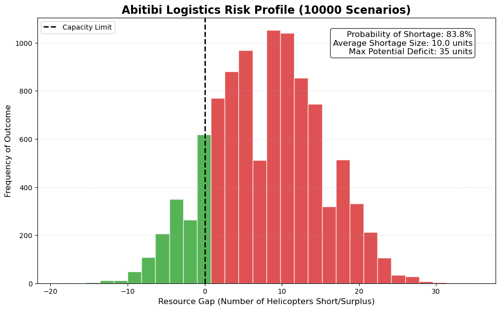

```
--- Simulation Complete ---
Risk of logistical failure (Shortage): 83.8%
```

```python
import numpy as np
import matplotlib.pyplot as plt

# 1. Configuration
n_simulations = 10000
total_flagged_projects = 58  # From our Step 4 analysis

# 2. Variable 1: Project Activation Rate (Stochastic)
# Not every permit leads to a drill. We model this as a random integer
# between 60% and 90% of the total flagged projects.
active_projects_sim = np.random.randint(
    int(total_flagged_projects * 0.6),
    int(total_flagged_projects * 0.9),
    n_simulations
)

# 3. Variable 2: Fleet Availability (Stochastic)
# Capacity fluctuates due to SOPFEU needs and maintenance.
# We model this with a Normal Distribution (Mean=35, SD=5)
fleet_capacity_sim = np.random.normal(loc=35, scale=5, size=n_simulations).astype(int)

# 4. Calculate the Outcome (Shortfall or Surplus)
# Positive numbers = Shortfall (Crisis)
# Negative numbers = Surplus (Safety margin)
shortfall_results = active_projects_sim - fleet_capacity_sim

# 5. Analysis Metrics
risk_of_shortfall = (shortfall_results > 0).mean()
avg_shortage = shortfall_results[shortfall_results > 0].mean() if risk_of_shortfall > 0 else 0

# 6. Visualization
plt.figure(figsize=(12, 7))

# Create the histogram
n, bins, patches = plt.hist(shortfall_results, bins=30, edgecolor='white', alpha=0.8)

# Color the "Crisis" zone red and the "Safe" zone green
for i in range(len(patches)):
    if bins[i] > 0:
        patches[i].set_facecolor('#d62728')  # Red for shortfall
    else:
        patches[i].set_facecolor('#2ca02c')  # Green for surplus

plt.axvline(0, color='black', linestyle='--', linewidth=2, label="Capacity Limit")
plt.title(f"Abitibi Logistics Risk Profile ({n_simulations} Scenarios)", fontsize=16, fontweight='bold')
plt.xlabel("Resource Gap (Number of Helicopters Short/Surplus)", fontsize=12)
plt.ylabel("Frequency of Outcome", fontsize=12)
plt.grid(axis='y', linestyle=':', alpha=0.6)

# Add a text box with the key stats
stats_text = (f"Probability of Shortage: {risk_of_shortfall:.1%}\n"
              f"Average Shortage Size: {avg_shortage:.1f} units\n"
              f"Max Potential Deficit: {shortfall_results.max()} units")

plt.gca().text(0.95, 0.95, stats_text, transform=plt.gca().transAxes, fontsize=12,
               verticalalignment='top', horizontalalignment='right',
               bbox=dict(boxstyle='round', facecolor='white', alpha=0.8))

plt.legend(loc='upper left')
plt.show()

print("--- Simulation Complete ---")
print(f"Risk of logistical failure (Shortage): {risk_of_shortfall:.1%}")
```

Recommendation: Based on this data, the approach is to immediately pivot from searching for local availability to securing external mobilization. This model provides the quantitative justification for the higher upfront cost of bringing in outside aircraft; the "cost of inaction"—having diamond drill rigs sit idle waiting for a local move—represents a far greater financial risk to the exploration program.